# Lab4

Muhamad Imran Bin Maszeri

10/7/2020

```r
library(readxl)
library(ggplot2)
library(tidyverse)
library(dplyr)

defense <- read_excel("cyclonesFootball2019.xlsx", sheet='Defensive')
str(defense)
```

```
## tibble [502 x 11] (S3: tbl_df/tbl/data.frame)
##  $ Name             : chr [1:502] "White, Lawrence" "White, Lawrence" "White, Lawrence" "White, Lawrence" ...
##  $ Opponent_Opponent: chr [1:502] "UNI" "Iowa" "ULM" "Baylor" ...
##  $ Tackles_Solo     : chr [1:502] "4" "4" "3" "4" ...
##  $ Tackles_ASST     : chr [1:502] "4" "7" "5" "2" ...
##  $ Tackles_TFL      : chr [1:502] "0" "0" "0" "0" ...
##  $ Tackles_Sack     : chr [1:502] "0" "0" "0" "0" ...
##  $ Turnover_FF      : chr [1:502] "0" "0" "0" "0" ...
##  $ Turnover_FR      : chr [1:502] "0" "0" "0" "0" ...
##  $ Turnover_INT     : chr [1:502] "0" "0" "1" "0" ...
##  $ Pass_QBH         : chr [1:502] "1" "0" "0" "0" ...
##  $ Pass_PB          : chr [1:502] "1" "2" "0" "0" ...
```

```r
offense <- read_excel("cyclonesFootball2019.xlsx", sheet='Offensive')
str(offense)
```

```
## tibble [195 x 12] (S3: tbl_df/tbl/data.frame)
##  $ Name             : chr [1:195] "Akers, Landen" "Akers, Landen" "Akers, Landen" "Akers, Landen" ...
##  $ Opponent_Opponent: chr [1:195] "UNI" "Iowa" "ULM" "Baylor" ...
##  $ Rushing_ATT      : chr [1:195] "0" "0" "1" "0" ...
##  $ Rushing_YDS      : chr [1:195] "0" "0" "8" "0" ...
##  $ Rushing_TD       : chr [1:195] "0" "0" "0" "0" ...
##  $ Receiving_REC    : chr [1:195] "1" "0" "0" "0" ...
##  $ Receiving_YDS    : chr [1:195] "21" "0" "0" "0" ...
##  $ Receiving_TD     : chr [1:195] "0" "0" "0" "0" ...
##  $ Passing_CMP-ATT  : chr [1:195] NA NA NA NA ...
##  $ Passing_YDS      : chr [1:195] NA NA NA NA ...
##  $ Passing_TD       : chr [1:195] NA NA NA NA ...
##  $ Passing_INT      : chr [1:195] NA NA NA NA ...
```

```r
bio <- read_excel("cyclonesFootball2019.xlsx", sheet='Biography')
str(bio)
```

```
## tibble [105 x 7] (S3: tbl_df/tbl/data.frame)
##  $ Name      : chr [1:105] "Akers, Landen" "Allen, Chase" "Anderson, Ezeriah" "Assalley, Connor" ...
##  $ Position  : chr [1:105] "Wide Receiver" "Tight End" "Wide Receiver" "Placekicker" ...
##  $ Height    : chr [1:105] "6-0" "6-7" "6-5" "6-0" ...
##  $ Weight    : chr [1:105] "188" "245" "204" "195" ...
##  $ Class     : chr [1:105] "Redshirt Senior" "Redshirt Senior" "Redshirt Freshman" "Redshirt Senior" ...
##  $ Hometown  : chr [1:105] "Cedar Rapids, Iowa" "Nixa, Mo." "Seffner, Fla." "Naperville, Ill." ...
##  $ Highschool: chr [1:105] "Washington" "Nixa" "Armwood" "Central" ...
```

```r
defense2018 <- read_excel("cyclonesFootball2018.xlsx", sheet='Defensive')
str(defense2018)
```

```
## tibble [446 x 11] (S3: tbl_df/tbl/data.frame)
##  $ Name             : chr [1:446] "Eisworth, Greg" "Eisworth, Greg" "Eisworth, Greg" "Eisworth, Greg" ...
##  $ Opponent_Opponent: chr [1:446] "Iowa" "Oklahoma" "Akron" "TCU" ...
##  $ Tackles_Solo     : chr [1:446] "3" "6" "7" "6" ...
##  $ Tackles_ASST     : chr [1:446] "3" "8" "2" "3" ...
##  $ Tackles_TFL      : chr [1:446] "0" "1.0" "1.0" "0" ...
##  $ Tackles_Sack     : chr [1:446] "0" "0" "0" "0" ...
##  $ Turnover_FF      : chr [1:446] "0" "1" "0" "0" ...
##  $ Turnover_FR      : chr [1:446] "0" "0" "0" "0" ...
##  $ Turnover_INT     : chr [1:446] "0" "0" "0" "0" ...
##  $ Pass_QBH         : chr [1:446] "0" "0" "0" "0" ...
##  $ Pass_PB          : chr [1:446] "0" "0" "3" "0" ...
```

```r
offense2018 <- read_excel("cyclonesFootball2018.xlsx", sheet='Offensive')
str(offense2018)
```

```
## tibble [168 x 12] (S3: tbl_df/tbl/data.frame)
##  $ Name             : chr [1:168] "Jones, Deshaunte" "Jones, Deshaunte" "Jones, Deshaunte" "Jones, Deshaunte" ...
##  $ Opponent_Opponent: chr [1:168] "Iowa" "Oklahoma" "Akron" "TCU" ...
##  $ Receiving_REC    : chr [1:168] "1" "9" "6" "3" ...
##  $ Receiving_YDS    : chr [1:168] "31" "66" "39" "23" ...
##  $ Receiving_TD     : chr [1:168] "0" "0" "0" "0" ...
##  $ Rushing_ATT      : chr [1:168] NA NA NA NA ...
##  $ Rushing_YDS      : chr [1:168] NA NA NA NA ...
##  $ Rushing_TD       : chr [1:168] NA NA NA NA ...
##  $ Passing_CMP-ATT  : chr [1:168] NA NA NA NA ...
##  $ Passing_YDS      : chr [1:168] NA NA NA NA ...
##  $ Passing_TD       : chr [1:168] NA NA NA NA ...
##  $ Passing_INT      : chr [1:168] NA NA NA NA ...
```

```r
bio2018 <- read_excel("cyclonesFootball2018.xlsx", sheet='Biography')
str(bio2018)
```

```
## tibble [123 x 7] (S3: tbl_df/tbl/data.frame)
##  $ Name      : chr [1:123] "Akers, Landen" "Allen, Chase" "Alt, Gerry" "Anderson, Cole" ...
##  $ Position  : chr [1:123] "Wide Receiver" "Tight End" "Offensive Line" "Tight End" ...
##  $ Height    : chr [1:123] "6-0" "6-7" "6-2" "6-4" ...
##  $ Weight    : chr [1:123] "192" "240" "290" "250" ...
##  $ Class     : chr [1:123] "Redshirt Sophomore" "Redshirt Sophomore" "Redshirt Freshman" "Redshirt Senior" ...
##  $ Hometown  : chr [1:123] "Cedar Rapids, Iowa" "Nixa, Mo." "Cedar Rapids, Iowa" "League City, Texas" ...
##  $ Highschool: chr [1:123] "Washington" "Nixa" "Washington" "Clear Falls" ...
```

## Part one: Cleaning data

Although the three Excel sheets are loaded into R, they are not useful before some cleaning. Manipulate the three imported data frames, so that in the cleaned dataset:

1. The player names and opponent names are factors.

```r
defClean <- defense %>%
  mutate_at(c('Name', 'Opponent_Opponent'), factor)
offClean <- offense %>%
  mutate_at(c('Name', 'Opponent_Opponent'), factor)
bioClean <- bio %>%
  mutate_at(c('Name'), factor)

str(defClean)
```

```
## tibble [502 x 11] (S3: tbl_df/tbl/data.frame)
##  $ Name             : Factor w/ 43 levels "Akers, Landen",..: 40 40 40 40 40 40 40 40 40 40 ...
##  $ Opponent_Opponent: Factor w/ 13 levels "Baylor","Iowa",..: 12 2 11 1 8 13 10 7 6 9 ...
##  $ Tackles_Solo     : chr [1:502] "4" "4" "3" "4" ...
##  $ Tackles_ASST     : chr [1:502] "4" "7" "5" "2" ...
##  $ Tackles_TFL      : chr [1:502] "0" "0" "0" "0" ...
##  $ Tackles_Sack     : chr [1:502] "0" "0" "0" "0" ...
##  $ Turnover_FF      : chr [1:502] "0" "0" "0" "0" ...
##  $ Turnover_FR      : chr [1:502] "0" "0" "0" "0" ...
##  $ Turnover_INT     : chr [1:502] "0" "0" "1" "0" ...
##  $ Pass_QBH         : chr [1:502] "1" "0" "0" "0" ...
##  $ Pass_PB          : chr [1:502] "1" "2" "0" "0" ...
```

```r
str(offClean)
```

```
## tibble [195 x 12] (S3: tbl_df/tbl/data.frame)
##  $ Name             : Factor w/ 17 levels "Akers, Landen",..: 1 1 1 1 1 1 1 1 1 1 ...
##  $ Opponent_Opponent: Factor w/ 13 levels "Baylor","Iowa",..: 12 2 11 1 8 13 10 7 6 9 ...
##  $ Rushing_ATT      : chr [1:195] "0" "0" "1" "0" ...
##  $ Rushing_YDS      : chr [1:195] "0" "0" "8" "0" ...
##  $ Rushing_TD       : chr [1:195] "0" "0" "0" "0" ...
##  $ Receiving_REC    : chr [1:195] "1" "0" "0" "0" ...
##  $ Receiving_YDS    : chr [1:195] "21" "0" "0" "0" ...
##  $ Receiving_TD     : chr [1:195] "0" "0" "0" "0" ...
##  $ Passing_CMP-ATT  : chr [1:195] NA NA NA NA ...
##  $ Passing_YDS      : chr [1:195] NA NA NA NA ...
##  $ Passing_TD       : chr [1:195] NA NA NA NA ...
##  $ Passing_INT      : chr [1:195] NA NA NA NA ...
```

```r
str(bioClean)
```

```
## tibble [105 x 7] (S3: tbl_df/tbl/data.frame)
##  $ Name      : Factor w/ 105 levels "Akers, Landen",..: 1 2 3 4 5 6 7 8 9 10 ...
##  $ Position  : chr [1:105] "Wide Receiver" "Tight End" "Wide Receiver" "Placekicker" ...
##  $ Height    : chr [1:105] "6-0" "6-7" "6-5" "6-0" ...
##  $ Weight    : chr [1:105] "188" "245" "204" "195" ...
##  $ Class     : chr [1:105] "Redshirt Senior" "Redshirt Senior" "Redshirt Freshman" "Redshirt Senior" ...
##  $ Hometown  : chr [1:105] "Cedar Rapids, Iowa" "Nixa, Mo." "Seffner, Fla." "Naperville, Ill." ...
##  $ Highschool: chr [1:105] "Washington" "Nixa" "Armwood" "Central" ...
```

2. All offensive and defensive statistics are numerical. The Weight column in biogrpahy is also numeric. (Optional: Learn to mutate multiple columns systematically using the ?across function in `dplyr)

```r
defClean <- defClean %>%
  mutate(across(where(is.character), as.numeric)) %>%
  mutate_at(c(3:11), ~replace(., is.na(.), 0))
offClean <- offClean %>%
  mutate(across(where(is.character), as.numeric)) %>%
  mutate_at(c(3:12), ~replace(., is.na(.), 0))
bioClean <- bioClean %>%
  mutate(across(starts_with("Weight"), as.numeric))

str(defClean)
```

```
## tibble [502 x 11] (S3: tbl_df/tbl/data.frame)
##  $ Name             : Factor w/ 43 levels "Akers, Landen",..: 40 40 40 40 40 40 40 40 40 40 ...
##  $ Opponent_Opponent: Factor w/ 13 levels "Baylor","Iowa",..: 12 2 11 1 8 13 10 7 6 9 ...
##  $ Tackles_Solo     : num [1:502] 4 4 3 4 3 1 7 3 6 5 ...
##  $ Tackles_ASST     : num [1:502] 4 7 5 2 2 1 1 2 1 5 ...
##  $ Tackles_TFL      : num [1:502] 0 0 0 0 1 0 0 0 1 1 ...
##  $ Tackles_Sack     : num [1:502] 0 0 0 0 0 0 0 0 0 1 ...
##  $ Turnover_FF      : num [1:502] 0 0 0 0 0 0 0 0 0 0 ...
##  $ Turnover_FR      : num [1:502] 0 0 0 0 0 0 0 0 0 0 ...
##  $ Turnover_INT     : num [1:502] 0 0 1 0 0 0 0 0 1 0 ...
##  $ Pass_QBH         : num [1:502] 1 0 0 0 0 0 0 0 1 0 ...
##  $ Pass_PB          : num [1:502] 1 2 0 0 0 1 0 0 0 0 ...
```

```r
str(offClean)
```

```
## tibble [195 x 12] (S3: tbl_df/tbl/data.frame)
##  $ Name             : Factor w/ 17 levels "Akers, Landen",..: 1 1 1 1 1 1 1 1 1 1 ...
##  $ Opponent_Opponent: Factor w/ 13 levels "Baylor","Iowa",..: 12 2 11 1 8 13 10 7 6 9 ...
##  $ Rushing_ATT      : num [1:195] 0 0 1 0 0 0 0 0 0 0 ...
##  $ Rushing_YDS      : num [1:195] 0 0 8 0 0 0 0 0 0 0 ...
##  $ Rushing_TD       : num [1:195] 0 0 0 0 0 0 0 0 0 0 ...
##  $ Receiving_REC    : num [1:195] 1 0 0 0 1 0 0 4 0 1 ...
##  $ Receiving_YDS    : num [1:195] 21 0 0 0 32 0 0 39 0 7 ...
##  $ Receiving_TD     : num [1:195] 0 0 0 0 0 0 0 0 0 0 ...
##  $ Passing_CMP-ATT  : num [1:195] 0 0 0 0 0 0 0 0 0 0 ...
##  $ Passing_YDS      : num [1:195] 0 0 0 0 0 0 0 0 0 0 ...
##  $ Passing_TD       : num [1:195] 0 0 0 0 0 0 0 0 0 0 ...
##  $ Passing_INT      : num [1:195] 0 0 0 0 0 0 0 0 0 0 ...
```

```r
str(bioClean)
```

```
## tibble [105 x 7] (S3: tbl_df/tbl/data.frame)
##  $ Name      : Factor w/ 105 levels "Akers, Landen",..: 1 2 3 4 5 6 7 8 9 10 ...
##  $ Position  : chr [1:105] "Wide Receiver" "Tight End" "Wide Receiver" "Placekicker" ...
##  $ Height    : chr [1:105] "6-0" "6-7" "6-5" "6-0" ...
##  $ Weight    : num [1:105] 188 245 204 195 190 235 255 285 300 215 ...
##  $ Class     : chr [1:105] "Redshirt Senior" "Redshirt Senior" "Redshirt Freshman" "Redshirt Senior" ...
##  $ Hometown  : chr [1:105] "Cedar Rapids, Iowa" "Nixa, Mo." "Seffner, Fla." "Naperville, Ill." ...
##  $ Highschool: chr [1:105] "Washington" "Nixa" "Armwood" "Central" ...
```

3. Change the Height column in biogrpahy into numeric. (Hint: Use a unit that works well)

```r
bioClean <- bioClean %>%
  separate(Height, c("feet","inches"), "-") %>%
  mutate(across(c("feet","inches"), as.numeric)) %>%
  mutate(cm_height=(feet*30.48) + cm(inches)) %>%
  select(!c("feet","inches"))
str(bioClean)
```

```
## tibble [105 x 7] (S3: tbl_df/tbl/data.frame)
##  $ Name      : Factor w/ 105 levels "Akers, Landen",..: 1 2 3 4 5 6 7 8 9 10 ...
##  $ Position  : chr [1:105] "Wide Receiver" "Tight End" "Wide Receiver" "Placekicker" ...
##  $ Weight    : num [1:105] 188 245 204 195 190 235 255 285 300 215 ...
##  $ Class     : chr [1:105] "Redshirt Senior" "Redshirt Senior" "Redshirt Freshman" "Redshirt Senior" ...
##  $ Hometown  : chr [1:105] "Cedar Rapids, Iowa" "Nixa, Mo." "Seffner, Fla." "Naperville, Ill." ...
##  $ Highschool: chr [1:105] "Washington" "Nixa" "Armwood" "Central" ...
##  $ cm_height : num [1:105] 183 201 196 183 183 ...
```

## Part two: Tidying

For the following questions, work on the cleaned data frames defClean, offClean, and bioClean.

1. Reformat the defClean data frame into a tidy format using pivot_longer. The type of statistic (Tackles_Solo, Tackles_ASST, etc) is added as a new key column named stat.

```r
defClean <- defClean %>%
  pivot_longer(Tackles_Solo:Pass_PB, names_to='stat')

str(defClean)
```

```
## tibble [4,518 x 4] (S3: tbl_df/tbl/data.frame)
##  $ Name             : Factor w/ 43 levels "Akers, Landen",..: 40 40 40 40 40 40 40 40 40 40 ...
##  $ Opponent_Opponent: Factor w/ 13 levels "Baylor","Iowa",..: 12 12 12 12 12 12 12 12 12 2 ...
##  $ stat             : chr [1:4518] "Tackles_Solo" "Tackles_ASST" "Tackles_TFL" "Tackles_Sack" ...
##  $ value            : num [1:4518] 4 4 0 0 0 0 0 1 1 4 ...
```

2. Compare the distributions of the defensive statistics. What defensive skills are rare?

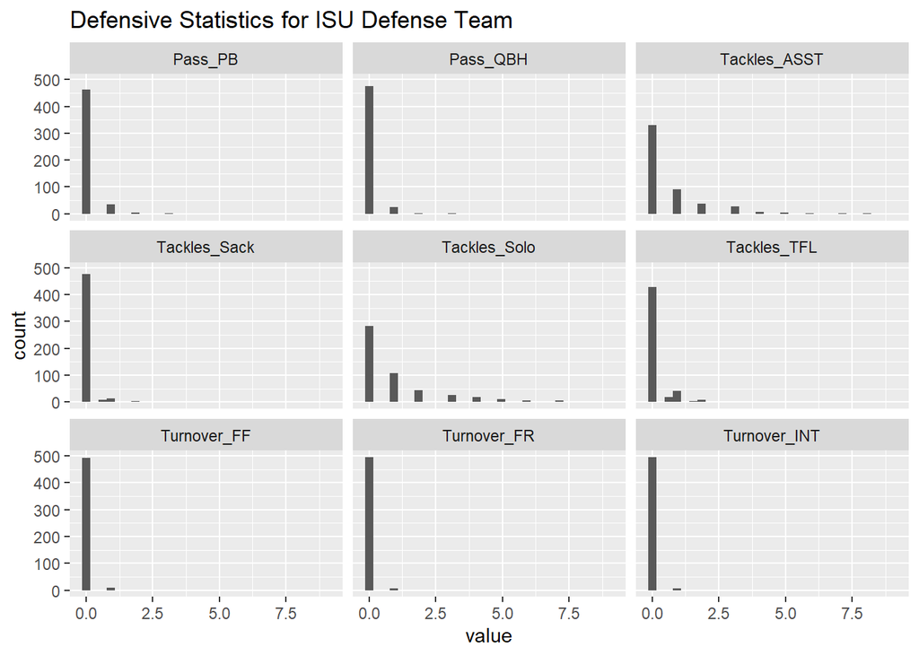

```r
defClean %>%
  ggplot(aes(value)) + geom_histogram() + facet_wrap(~stat) +
  labs(title="Defensive Statistics for ISU Defense Team")
```

Answer: The defensive skills that are rare are; Pass_PB, Pass_QBH, Tackles_Sack, Turnover_FF, Turnover_FR and Turnover_INT.

3. Did ISU have better defense against Iowa or Notre Dame? Answer this question by creating a scatterplot with x- and y-axes being the number of solo tackles (of each player). A large number of solo tackles is an indicator of good defense.

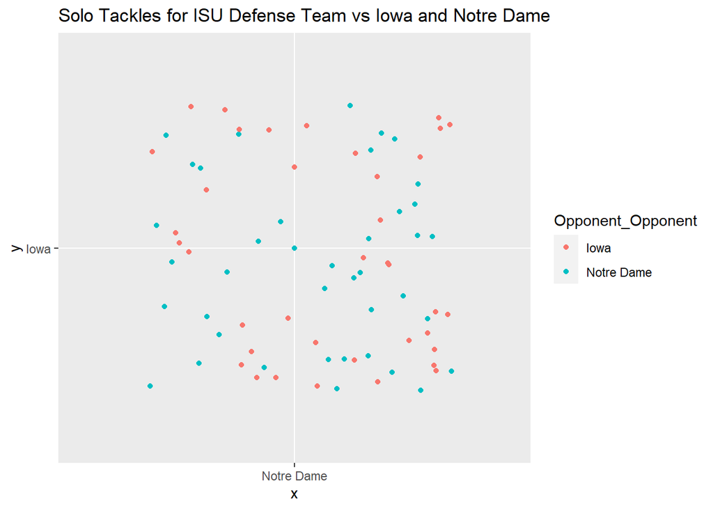

```r
defClean %>%
  filter(Opponent_Opponent %in% c('Iowa', 'Notre Dame'), stat=='Tackles_Solo') %>%
  ggplot(aes('Notre Dame', 'Iowa', color=Opponent_Opponent)) + geom_point() + geom_jitter() + labs(title="Solo Tackles for ISU Defense Team vs Iowa and Notre Dame", legend="Opponent")
```

Now turn our attention to the player biography.

4. Separate the Hometown column into two columns, namely the city and the state. Print the first few rows of these two columns. (Hint: look at the sep= argument of separate)

```r
bioClean <- bioClean %>%
  separate(Hometown, c("city","state"), ",")

head(bioClean)
```

```
## # A tibble: 6 x 8
##   Name        Position    Weight Class      city     state  Highschool cm_height
##   <fct>       <chr>        <dbl> <chr>      <chr>    <chr>  <chr>          <dbl>
## 1 Akers, Lan~ Wide Recei~    188 Redshirt ~ Cedar R~ " Iow~ Washington      183.
## 2 Allen, Cha~ Tight End      245 Redshirt ~ Nixa     " Mo." Nixa            201.
## 3 Anderson, ~ Wide Recei~    204 Redshirt ~ Seffner  " Fla~ Armwood         196.
## 4 Assalley, ~ Placekicker    195 Redshirt ~ Napervi~ " Ill~ Central         183.
## 5 Azunna, Ar~ Defensive ~    190 Redshirt ~ Grand P~ " Tex~ Lake Ridge      183.
## 6 Bailey, Co~ Defensive ~    235 Redshirt ~ Clarksd~ " Mis~ Clarksdale      190.
```

5. How many players are there from each state?

```r
bioClean %>%
  group_by(state) %>%
  summarise(nState=n()) %>%
  arrange(desc(nState))
```

```
## # A tibble: 19 x 2
##    state        nState
##    <chr>         <int>
##  1 " Iowa"          35
##  2 " Fla."          10
##  3 " Ohio"           7
##  4 " Mo."            6
##  5 " Texas"          6
##  6 " Wis."           6
##  7 " Ill."           5
##  8 " Ariz."          4
##  9 " Ga."            4
## 10 " Mich."          4
## 11 " Minn."          4
## 12 " Calif."         3
## 13 " Kan."           3
## 14 " Okla."          2
## 15 " S.D."           2
## 16 " Ark."           1
## 17 " Australia"      1
## 18 " Miss."          1
## 19 " Pa."            1
```

Answer: There are a total of 35 players from Iowa, the most amount in the team.

## Part three: Joining data frames

1. Find which states do the ISU defensive and offensive players come from. Create an appropriate summary.

```r
offState <- offClean %>%
  select(Name) %>%
  distinct() %>%
  left_join(bioClean, by=c("Name"))

offState %>%
  group_by(state) %>%
  drop_na() %>%
  summarise(nState=n()) %>%
  arrange(desc(nState))
```

```
## # A tibble: 11 x 2
##    state    nState
##    <chr>     <int>
##  1 " Fla."       2
##  2 " Okla."      2
##  3 " Ariz."      1
##  4 " Ark."       1
##  5 " Ga."        1
##  6 " Ill."       1
##  7 " Iowa"       1
##  8 " Kan."       1
##  9 " Mo."        1
## 10 " Ohio"       1
## 11 " Texas"      1
```

```r
defState <- defClean %>%
  pivot_wider(names_from='stat', values_from='value') %>%
  select(Name) %>%
  distinct() %>%
  left_join(bioClean, by=c("Name"))

defState %>%
  group_by(state) %>%
  drop_na() %>%
  summarise(nState=n()) %>%
  arrange(desc(nState))
```

```
## # A tibble: 12 x 2
##    state     nState
##    <chr>      <int>
##  1 " Iowa"        7
##  2 " Fla."        4
##  3 " Ga."         3
##  4 " Ohio"        3
##  5 " Calif."      2
##  6 " Mo."         2
##  7 " Okla."       2
##  8 " Texas"       2
##  9 " Wis."        2
## 10 " Ark."        1
## 11 " Kan."        1
## 12 " Mich."       1
```

Answer: Most offense team is from Florida and Oklahoma, and most defense team is from Iowa

2. How does the performance of quarterback Brock Purdy relate to the performance of the ISU team?

```r
purdy <- offClean %>%
  filter(Name=="Purdy, Brock")

purdy %>%
  select(c(Opponent_Opponent, Passing_YDS, Passing_INT)) %>%
  arrange(desc(Passing_YDS)) %>%
  head()
```

```
## # A tibble: 6 x 3
##   Opponent_Opponent Passing_YDS Passing_INT
##   <fct>                   <dbl>       <dbl>
## 1 ULM                       435           1
## 2 Oklahoma State            382           3
## 3 Texas Tech                378           1
## 4 Kansas                    372           1
## 5 Texas                     354           1
## 6 Baylor                    342           1
```

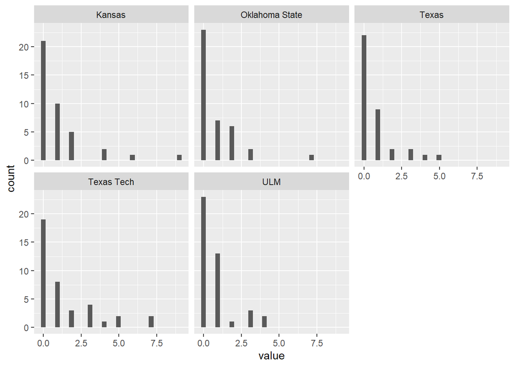

```r
defClean %>%
  filter(Opponent_Opponent %in% c('ULM', 'Oklahoma State', 'Texas Tech', 'Kansas', 'Texas'), stat=='Tackles_Solo') %>%
  ggplot(aes(value)) + geom_histogram() + facet_wrap(~Opponent_Opponent)
```

```r
offClean %>%
  filter(Opponent_Opponent %in% c('ULM', 'Oklahoma State', 'Texas Tech', 'Kansas', 'Texas')) %>%
  mutate(total_offense= Receiving_REC   + Receiving_YDS + Receiving_TD) %>%
  select(Opponent_Opponent, total_offense) %>%
  group_by(Opponent_Opponent) %>%
  drop_na() %>%
  summarise(totalOff=sum(total_offense)) %>%
  arrange(desc(totalOff))
```

```
## # A tibble: 5 x 2
##   Opponent_Opponent totalOff
##   <fct>                <dbl>
## 1 ULM                    470
## 2 Oklahoma State         422
## 3 Kansas                 405
## 4 Texas Tech             404
## 5 Texas                  386
```

3. Which ISU player(s) made big progress over the last year? Compare the 2019 and the 2018 data here.

```r
offClean2018 <- offense2018 %>%
  mutate_at(c('Name', 'Opponent_Opponent'), factor) %>%
  mutate(across(where(is.character), as.numeric)) %>%
  mutate_at(c(3:12), ~replace(., is.na(.), 0))

off_team2018 <- offClean2018 %>%
  mutate(sum = Receiving_REC    + Receiving_YDS + Receiving_TD) %>%
  select(Name, sum) %>%
  group_by(Name) %>%
  drop_na() %>%
  summarise(team_offense2018=sum(sum)) %>%
  arrange(desc(team_offense2018))

off_team2019 <- offClean %>%
  mutate(sum = Receiving_REC + Receiving_YDS + Receiving_TD) %>%
  select(Name, sum) %>%
  group_by(Name) %>%
  drop_na() %>%
  summarise(team_offense2019=sum(sum)) %>%
  arrange(desc(team_offense2019))

off_team2019 %>%
  left_join(off_team2018, by=c('Name')) %>%
  group_by(Name) %>%
  mutate(off_points=team_offense2019-team_offense2018) %>%
  select(Name, off_points) %>%
  arrange(desc(off_points)) %>%
  head()
```

```
## # A tibble: 6 x 2
## # Groups:   Name [6]
##   Name             off_points
##   <fct>                 <dbl>
## 1 Kolar, Charlie          604
## 2 Jones, Deshaunte        542
## 3 Milton, Tarique         308
## 4 Allen, Chase             94
## 5 Lang, Johnnie            29
## 6 Purdy, Brock              0
```

```r
defClean2018 <- defense2018 %>%
  mutate_at(c('Name', 'Opponent_Opponent'), factor) %>%
  mutate(across(where(is.character), as.numeric)) %>%
  mutate_at(c(3:11), ~replace(., is.na(.), 0))

def_tackle2019 <- defClean %>%
  pivot_wider(names_from='stat', values_from='value')

defClean2018 %>%
  left_join(def_tackle2019, by=c('Name','Opponent_Opponent')) %>%
  select(Name, Tackles_Solo.x, Tackles_Solo.y) %>%
  mutate(total_tackles=Tackles_Solo.y-Tackles_Solo.x) %>%
  select(Name, total_tackles) %>%
  arrange(desc(total_tackles)) %>%
  head()
```

```
## # A tibble: 6 x 2
##   Name              total_tackles
##   <fct>                     <dbl>
## 1 Johnson , Anthony             7
## 2 Lewis, Braxton                6
## 3 Vance, O'Rien                 6
## 4 Vance, O'Rien                 6
## 5 Lewis, Braxton                5
## 6 White, Lawrence               5
```

Answer: Charlie Kolar has the highest improvement in total offense points, where he has an increase of 604 points. Anthony Johnson has the highest solo tackle improvement overall, with an increase of 7 total tackles.